# INApest `FecundityReduction`

**Model implementation, validation, demonstration and full repeatability record**

Audience: expert population, invasion and spatial modellers with little or no prior knowledge of INApest · 19 August 2026

# Executive summary

The INApestMeta model family already represented management that removes individuals and management that reduces onward dispersal. It lacked a separate mechanism for management that leaves individuals alive but lowers their reproductive output. The `FecundityReduction` upgrade adds that mechanism while preserving the previous behaviour at the default value zero.

3

Meta model structures support fecundity management

14 / 14

parameterisation and edge-case smoke checks passed

12 / 12

saved serial/parallel outputs matched exactly on the executable one-core path

9 / 9

MLU and transition-matrix input shapes matched across serial/parallel-function paths

6 / 6

archived evidence CSVs reproduced byte-for-byte with the latest source defaults

**Mechanistic definition.** Management mortality is realised first. `FecundityReduction` then reduces the per-capita reproductive output of the survivors, and only in units that are currently managed. It is therefore not a second mortality term and is not a global rescaling of baseline fecundity.

**Reproducibility result.** The full original fecundity validation suite was rerun against the current source files—which now also contain restored custom `LocalDynamics` hooks and optional transition movement. With those later features at their defaults, every archived CSV evidence file was reproduced byte-for-byte.

**Parallel caveat.** Exact serial/parallel equality was demonstrated on the parallel functions' one-core fallback, where the RNG stream is shared. A genuine multi-worker PSOCK run intentionally uses independent worker RNG streams, so exact realisation-by-realisation equality is neither expected nor the correct criterion. A separate native-R Monte Carlo equivalence test is included and must be run on a machine where PSOCK workers can actually be created.

# 1. INApest model family: the minimum needed to read this report

INApest is a family of discrete-time stochastic invasion-response models defined on a network of spatial nodes. A node can represent a farm, management unit, grid cell or other spatial unit. Replicate simulations (`Nperm`) propagate biological state and response state through `Ntimesteps`. Connectivity matrices describe short-distance dispersal (SDD), optional long-distance dispersal (LDD), and—separately—information exchange where supplied.

Ordinary Meta

One abundance value per node. Local survival, management mortality, reproduction, dispersal, recruitment and carrying capacity update node abundance.

state: node

Multiple-land-use Meta

Each node contains an explicit abundance vector over land uses. Management effects can differ among those land uses before the node's propagules are pooled.

state: node × land use

Transition-matrix Meta

Each node contains a stage vector. A stage transition matrix controls fecundity, stasis/progression and survival, with spatial dispersal and carrying capacities layered around that structure.

state: node × stage

## Where the new mechanism sits in a timestep

**Existing population**node / land-use / stage state

→

**Detection & management**information controls whether management is adopted

→

**Survival & mortality**natural survival and management mortality create surviving state *N*<sup>0</sup>

→

**Fecundity**`FecundityReduction` modifies reproductive output of managed survivors

**Propagule draw**Poisson production from effective reproductive contribution

→

**Dispersal**SDD and optional LDD; spread reduction acts on the management-sensitive LDD pathway

→

**Establishment & capacity**recruitment probability and available capacity determine additions

→

**Next state**saved and passed to the next timestep

The transition-matrix model contains additional stage-transition steps. The diagram isolates the location of fecundity management in the update sequence rather than reproducing every line of each model.

# 2. Why add `FecundityReduction`?

Mortality

Changes the number of individuals that survive management. In ordinary Meta, the survivor draw combines environmental survival and management mortality.

N⁰ ~ Binomial(N, Survival × (1 − MortalityProb × Managing))

Fecundity reduction

Changes the reproductive contribution of individuals that survived. It is applied only when the relevant node or land-use unit is managed.

effective reproduction = N⁰ × (1 − FecundityReduction × Managing)

Spread reduction

Acts later, on movement of propagules. In the current Meta defaults it reduces the management-sensitive LDD output, rather than changing how many propagules were produced.

LDD output ∝ propagules × LDDrate × (1 − SpreadReduction × Managing)

Keeping these pathways separate matters whenever management is sublethal, sterilising, growth-regulating, host-modifying, mating-disrupting or otherwise capable of lowering reproduction without killing the treated individuals. Collapsing such an effect into mortality changes abundance immediately; collapsing it into baseline `PropaguleProduction` changes reproduction even where management is absent. `FecundityReduction` instead represents a conditional management effect on per-capita reproduction.

# 3. Ordinary INApestMeta implementation

For node i at timestep t, let N⁰<sub>it</sub> be abundance after natural survival and management mortality, M<sub>it</sub> the binary management state, f<sub>it</sub> the fecundity reduction, and b<sub>it</sub> baseline propagule production per survivor.

Nrep_it = N⁰_it × (1 − f_it × M_it)

Propagules_it ~ Poisson( b_it × Nrep_it )

This is implemented in the default `local.dynamics` function as `EffectiveReproductivePopulation`, followed by the existing Poisson propagule draw. The transition from survivors to reproduction is therefore explicit: if management is absent, the multiplier is one; if `f = 1` and management is active, survivors remain in the population but contribute zero new propagules during that timestep.

**Default compatibility.** `FecundityReduction = 0` makes the multiplier exactly one. The original implementation check found zero numerical difference from the pre-upgrade MLU and transition-matrix serial models in the tested scenarios; the current-source scientific tables also reproduce the archived results exactly.

# 4. Multiple-land-use implementation: keep reproductive refuges explicit

The multiple-land-use model is the most important place not to collapse the new parameter too early. A node contains separate abundance components for each land use. Management status and fecundity suppression are therefore applied to each component **before** those contributions are summed to obtain node-level propagule production.

C_iℓt = N⁰_iℓt × (1 − f_iℓt × M_iℓt)

Propagules_it ~ Poisson( b_it × Σℓ C_iℓt )

Here C<sub>iℓt</sub> is the surviving reproductive contribution of land use ℓ. This is analogous to the refuge mechanism used elsewhere in the modelling work: the weakly affected component is kept separate long enough for the relevant process to act, rather than averaging its protection away at node level.

## Worked reproductive-refuge example

Land use 1

Post-mortality abundance: **40**  
Fecundity reduction: **0.1**

36

effective reproductive contribution (67% of node total)

Land use 2

Post-mortality abundance: **30**  
Fecundity reduction: **0.5**

15

effective reproductive contribution (28% of node total)

Land use 3

Post-mortality abundance: **30**  
Fecundity reduction: **0.9**

3

effective reproductive contribution (6% of node total)

The node contains 100 survivors, but effective reproductive abundance is only **54**. Land use 1 holds 40% of survivors yet supplies about **67%** of effective reproduction because its fecundity is weakly suppressed. At baseline propagule production 2, the node's Poisson mean is 108 rather than 200. This is the sense in which a land use can function as a **reproductive refuge**.

### SDD

The land-use contributions are summed to generate one node-level propagule pool. The natural/SDD component is then dispersed using the node-level SDD matrix. Land-use identity is not carried as a separate SDD network.

### LDD

Before the LDD component is reduced by land-use-specific `SpreadReduction`, the model weights the node's propagules by each land use's share of `FecundityContrib`. Thus land-use identity is retained where it is needed to combine fecundity and spread management.

Recruitment is subsequently allocated among land uses according to unoccupied land-use capacity. The crucial design choice is that `FecundityReduction` affects the land-use reproductive contribution before node pooling, not after it.

# 5. Transition-matrix implementation

In the stage-structured model, fecundity is encoded in the first row of the transition matrix. For stages s = 2,…,S, the first-row coefficient a<sub>1s</sub> is treated as per-capita fecundity of stage s. The supplied transition matrix is not modified. Instead, its fecundity coefficients are multiplied by the management-specific stage multipliers when the expected propagule count is calculated.

a′_1s,it = a_1s,it × (1 − f_ist × M_it)

λ_it = Σ(s=2…S) a′_1s,it × N⁰_ist ; Propagules_it ~ Poisson(λ_it)

This permits a treatment to suppress reproduction strongly in one reproductive stage but weakly in another. A node vector applies the same reduction to all stages within each node; a stage vector applies the same stage profile across nodes; the full array can vary by node, stage and timestep.

**Stage 1 convention.** A length-`Nstages` vector is accepted so indexing aligns with biological stage numbering, but element 1 is unused in the fecundity calculation because the active first-row fecundity coefficients correspond to stages `2:Nstages`. A dedicated test confirmed that changing only stage 1 reduction changes the output by exactly zero.

**Ambiguity protection.** If the number of nodes equals the number of stages, an unnamed vector of that shared length could mean either nodes or stages. The function rejects that case rather than guessing; users can supply a dimensioned node × timestep matrix or node × stage × timestep array.

The current transition-matrix source also supports optional movement during stage progression. That feature was added after the fecundity work and is not used in these fecundity demonstrations; its default-off setting was present in the latest-source rerun that reproduced the archived fecundity evidence exactly.

# 6. User-facing parameter contract

| Model | Static forms | Time-varying form | Resolved within timestep | Special rule |
| --- | --- | --- | --- | --- |
| Ordinary Meta | scalar; node vector | node × timestep matrix | current node value at timestep | no stage/land-use dimension |
| Multiple-land-use Meta | scalar; land-use vector; node × land-use matrix | node × land-use × timestep array | current node × land-use slice | land-use contribution reduced before node pooling |
| Transition-matrix Meta | scalar; node vector; stage vector | node × timestep matrix; node × stage × timestep array | current node × stage values | stage 1 unused; ambiguous node/stage vector rejected |

All values must be finite and within [0,1]. There is deliberately no `FecundityReductionSD`: the parameter expresses the management effect itself rather than adding another stochastic layer to the management-efficacy input.

# 7. Source architecture, parallel processing and custom local dynamics

## Default dynamics remain inspectable and replaceable

All current Meta serial and parallel source files expose a `LocalDynamics` argument. The current default dynamics function is defined in the same source file: `local.dynamics`, `local.dynamicsLU` or `local.dynamics.transition.matrix`. Users can therefore replace local biology without editing the main simulation driver.

For backward compatibility, an older custom function that lacks `nodefecundityreduction` still runs when `FecundityReduction = 0`. If fecundity management is active, the driver stops with an informative error unless the custom function accepts `nodefecundityreduction` or `...`. This prevents the management effect from being silently ignored.

| Current custom-LocalDynamics check | Status | Observed message |
| --- | --- | --- |
| old custom function FR zero | PASS |  |
| old custom function FR active errors | PASS | Custom LocalDynamics must accept a 'nodefecundityreduction' argument (or ...) when FecundityReduction is active |

## Parallel implementation

The active parallel source family was standardised on base-R PSOCK clusters and `parallel::parLapply()`. The selected `LocalDynamics` is forced before the worker closure is created, so the default or user-supplied function is part of the worker dependency. The transition-matrix parallel function no longer relies on a long manually maintained `clusterExport()` list that could omit new parameters.

The exact equivalence evidence below comes from the one-core fallback used by WebR; that path still executes the parallel function's worker body and result-combination code. The bundle's native PSOCK script is the test for the genuinely multi-process branch.

# 8. Repeatability design and provenance

The bundle deliberately retains two source states:

### Fecundity validation snapshot

The exact source snapshot used to generate the original archived fecundity evidence. It records the implementation state before the later transition-movement and full custom-`LocalDynamics` refinements.

`source/fecundity_validation_snapshot/`

### Current source snapshot

The latest source set at bundle assembly. It includes the fecundity upgrade, harmonised parallel processing, restored custom local dynamics, and the later transition-movement extension.

`source/latest/`

**Strong regression result.** Running the original fecundity validation workflow against *current* sources produced the same six CSV evidence files byte-for-byte. This is stronger than rounded numerical agreement: it shows the later default-off/default-equivalent refinements did not alter these recorded fecundity tests.

| Evidence file | Byte-identical: archived vs latest rerun |
| --- | --- |
| equivalence_results.csv | YES |
| parameterisation_smoke_results.csv | YES |
| parameterisation_parallel_equivalence.csv | YES |
| mortality_by_fecundity_results.csv | YES |
| landuse_mortality_fecundity_results.csv | YES |
| validation_environment.csv | YES |

## Current Meta source checksums

| File | Bytes | SHA-256 (prefix) |
| --- | --- | --- |
| INApestMeta.r | 40068 | 1ec6dbe80db96e60… |
| INApestMetaMultipleLandUse.r | 43753 | 52cafa9a18bf2c61… |
| INApestMetaParallel.r | 40654 | 1d87fec9b69270ed… |
| INApestMetaParallelMultipleLandUse.r | 44549 | 5eee2f7fec1c6dff… |
| INApestMetaTransitionMatrix.r | 91953 | 108a9e6026d7d2a7… |
| INApestMetaTransitionMatrixParallel.r | 78542 | 89f9cb37955b2144… |

Full SHA-256 values for both snapshots are in `docs/source_snapshot_manifest.csv`; the complete bundle also has a root checksum file.

# 9. Validation evidence

## Serial/parallel-function agreement in the executable one-core environment

| Model | Saved output | Status | Max absolute difference |
| --- | --- | --- | --- |
| INApest | Invasion | PASS | 0 |
| INApest | Info | PASS | 0 |
| INApest | Detected | PASS | 0 |
| INApestMetaMultipleLandUse | Population | PASS | 0 |
| INApestMetaMultipleLandUse | Invasion | PASS | 0 |
| INApestMetaMultipleLandUse | Info | PASS | 0 |
| INApestMetaMultipleLandUse | Detected | PASS | 0 |
| INApestMetaTransitionMatrix | PopulationStage | PASS | 0 |
| INApestMetaTransitionMatrix | Population | PASS | 0 |
| INApestMetaTransitionMatrix | Invasion | PASS | 0 |
| INApestMetaTransitionMatrix | Info | PASS | 0 |
| INApestMetaTransitionMatrix | Detected | PASS | 0 |

All 12 saved outputs compared exactly. This covered binary INApest as a reference for the common parallel architecture, MLU Meta, and transition-matrix Meta.

## Input-shape smoke tests

| Model | FecundityReduction parameterisation / edge case | Status |
| --- | --- | --- |
| Meta | scalar | PASS |
| Meta | node vector | PASS |
| Meta | node by timestep | PASS |
| Meta MLU | scalar | PASS |
| Meta MLU | landuse vector | PASS |
| Meta MLU | node by landuse | PASS |
| Meta MLU | node by landuse by timestep | PASS |
| Meta transition matrix | scalar | PASS |
| Meta transition matrix | node vector | PASS |
| Meta transition matrix | stage vector | PASS |
| Meta transition matrix | node by timestep | PASS |
| Meta transition matrix | node by stage by timestep | PASS |
| Meta transition matrix | stage1 value unused check | PASS |
| Meta transition matrix | ambiguous node stage vector error | PASS |

All agreed parameter forms executed. The two transition-matrix edge checks—unused stage-1 value and ambiguous node/stage vector—also behaved as designed.

**Serial/parallel equivalence for every MLU and transition-matrix input shape**

| Model | Shape | Status | Max absolute difference |
| --- | --- | --- | --- |
| Meta MLU | scalar | PASS | 0 |
| Meta MLU | landuse vector | PASS | 0 |
| Meta MLU | node by landuse | PASS | 0 |
| Meta MLU | node by landuse by timestep | PASS | 0 |
| Meta transition matrix | scalar | PASS | 0 |
| Meta transition matrix | node vector | PASS | 0 |
| Meta transition matrix | stage vector | PASS | 0 |
| Meta transition matrix | node by timestep | PASS | 0 |
| Meta transition matrix | node by stage by timestep | PASS | 0 |

## Current ordinary Meta serial counterpart

The serial ordinary `INApestMeta` function was restored/constructed after the initial fecundity snapshot. A supplemental current-source test now checks its three supported fecundity shapes against `INApestMetaParallel` on the same one-core RNG path.

| Shape | Status | Max absolute difference |
| --- | --- | --- |
| scalar | PASS | 0 |
| node vector | PASS | 0 |
| node by timestep | PASS | 0 |

## Backward compatibility and true multi-worker scope

### Fecundity default

The original executed regression check reported `max_abs_difference = 0` against the pre-change serial MLU and transition-matrix models when `FecundityReduction = 0`. The current source rerun further reproduces all archived evidence tables exactly.

### Native PSOCK

WebR cannot create native R subprocesses, so actual multi-worker PSOCK execution has not been run in this environment. `scripts/05_native_psock_validation_current.R` forces more than one worker and compares serial and parallel Monte Carlo summaries using a four-combined-SE criterion.

# 10. Demonstration simulations

**These are implementation demonstrations, not calibrated ecological predictions.** Connectivity is deliberately simplified (identity SDD, no LDD) so the population response can be attributed cleanly to mortality and fecundity management rather than spatial network effects.

## Mortality × fecundity reduction

The ordinary Meta demonstration used four nodes, six timesteps and 60 stochastic replicates for each of 15 combinations: management mortality 0, 0.3 or 0.6 crossed with fecundity reductions 0, 0.25, 0.5, 0.75 or 1. Baseline propagule production was 0.6 per survivor, establishment was 0.0015 and carrying capacity was 500 per node.

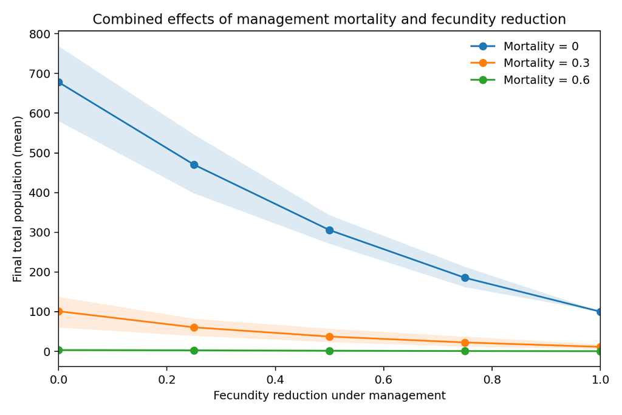

**Figure 1. Mortality and fecundity suppression act as separate, compounding mechanisms.** Lines/points show mean final total population; intervals show the archived 5th–95th percentile across 60 stochastic replicates. At zero management mortality, complete fecundity suppression leaves the initial 100 survivors but prevents new recruitment; when mortality is also active, both survivor number and subsequent reproduction decline.

| Mortality | Fecundity reduction | Mean final population | SD | 5th–95th percentile | Mean relative to FR=0 |
| --- | --- | --- | --- | --- | --- |
| 0 | 0 | 678 | 52.61 | 579.95–768.6 | 100% |
| 0 | 0.25 | 470.22 | 44.08 | 397.95–546.05 | 69.4% |
| 0 | 0.5 | 305.53 | 22.47 | 270.95–343 | 45.1% |
| 0 | 0.75 | 185.32 | 15.29 | 161.75–213 | 27.3% |
| 0 | 1 | 100 | 0 | 100–100 | 14.7% |
| 0.3 | 0 | 101.07 | 24.65 | 59.95–137.05 | 100% |
| 0.3 | 0.25 | 60.55 | 15.55 | 38.85–82.1 | 59.9% |
| 0.3 | 0.5 | 37.32 | 10.67 | 22.95–57.05 | 36.9% |
| 0.3 | 0.75 | 22.48 | 7.64 | 12–37 | 22.2% |
| 0.3 | 1 | 11.38 | 3.53 | 6–17.05 | 11.3% |
| 0.6 | 0 | 3.15 | 2.89 | 0–7.05 | 100% |
| 0.6 | 0.25 | 2.47 | 2.39 | 0–7.05 | 78.3% |
| 0.6 | 0.5 | 1.43 | 1.78 | 0–6.05 | 45.5% |
| 0.6 | 0.75 | 0.9 | 1.02 | 0–2.05 | 28.6% |
| 0.6 | 1 | 0.52 | 0.65 | 0–1.05 | 16.4% |

The response is monotonic within each mortality level but is not expected to be linear at the final-population scale: suppression acts upstream of stochastic propagule production and recruitment, so effects compound through six population updates. At mortality 0.3, increasing fecundity reduction from 0 to 0.5 reduces the mean final population from 101.1 to 37.3; at complete suppression it falls to 11.4.

## Land-use-specific fecundity reduction

The MLU experiment used three land uses. The first three nodes each contained one land use; the fourth was mixed. This design makes the land-use-specific mapping visible while also retaining a node in which the land-use contributions interact. The gradient treatment set fecundity reductions to 0, 0.5 and 0.9 across land uses.

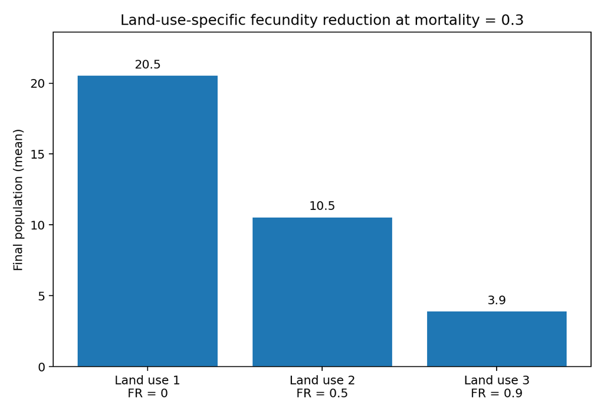

**Figure 2. The land-use vector is applied to separate reproductive contributions.** At management mortality 0.3, otherwise comparable single-land-use nodes finished at mean populations 20.5, 10.5 and 3.9 for fecundity reductions 0, 0.5 and 0.9. The ordering confirms that the vector is not collapsed to one node-level fecundity-reduction value before reproduction is calculated.

| Pattern | FR: LU1 / LU2 / LU3 | Mean final total | LU1 node | LU2 node | LU3 node | Mixed node |
| --- | --- | --- | --- | --- | --- | --- |
| none | 0 / 0 / 0 | 114.8 | 27.2 | 24.9 | 25.9 | 36.7 |
| uniform half | 0.5 / 0.5 / 0.5 | 42.7 | 9.5 | 9.8 | 10 | 13.5 |
| landuse gradient | 0 / 0.5 / 0.9 | 49.2 | 20.5 | 10.5 | 3.9 | 14.3 |
| uniform strong | 0.9 / 0.9 / 0.9 | 16.4 | 4 | 3.4 | 3.8 | 5.2 |

The gradient produces a larger final total than uniform 0.5 suppression because the unsuppressed land use remains a strong source. That is the operational meaning of a reproductive refuge: residual population in a weakly suppressed land use can contribute disproportionately to future propagules even when other parts of the same node are strongly affected.

# 11. How to reproduce the work

## Bundle structure

INApest_FecundityReduction_repeatability_bundle_2026-08-19/ ├── source/ │ ├── fecundity_validation_snapshot/ # exact source state behind archived evidence │ └── latest/ # current source state ├── inputs/ # parameter contract and scenario manifest ├── scripts/ │ ├── 00_run_all.R │ ├── 01_validate_fecundity_reduction_current.R │ ├── 02_current_meta_serial_parallel_smoke.R │ ├── 03_compare_archived_and_rerun.R │ ├── 04_plot_results.R │ ├── 05_native_psock_validation_current.R │ └── 06_reproduce_scientific_results_serial.R ├── results/ │ ├── archived/ # frozen original evidence │ ├── latest_rerun/ # current-source rerun in WebR │ ├── native_serial_reproduction/ # serial current-source reproduction │ └── webr_exact_rerun/ # exact rerun made from bundled WebR runtime ├── figures/ ├── environment/ │ ├── webr_runtime/ # working WebR 0.6.0 browser runtime │ ├── run_webr_exact_reproduction.py │ └── DEPENDENCIES.md ├── docs/ # original implementation report, patch, manifests └── report/ # this HTML and its build script

## Route A — ordinary native R: reproduce the scientific results

Rscript scripts/00_run_all.R

On a normal multi-core machine, the entry point uses serial current-source functions to reproduce the scientific smoke-test and demonstration tables without parallel RNG differences. The archived parameterisation, mortality × fecundity and land-use tables were independently reproduced exactly using this serial route under the recorded R runtime.

## Route B — validate actual multi-worker PSOCK

Rscript scripts/05_native_psock_validation_current.R

This requires at least three detected cores and intentionally forces the parallel functions to use more than one PSOCK worker. It tests distributional/Monte Carlo agreement with serial simulations rather than exact RNG identity.

## Route C — reproduce the archived one-core evidence exactly

python environment/run_webr_exact_reproduction.py

The WebR runtime used for the archived validation is bundled. The Python harness requires Playwright and a usable Chromium/Chrome installation. In this assembled bundle it reproduced all six archived evidence CSVs byte-for-byte. This route is primarily for provenance; most modelling work should use native R.

## Rebuild figures and report

`scripts/04_plot_results.R` regenerates the two demonstration figures from CSV evidence using base R graphics. `report/build_report.py` rebuilds this self-contained HTML from the saved result tables and figures.

# 12. Interpretation, scope and limitations

- **The demonstration effect sizes are not species estimates.** Their purpose is to show that the implemented mechanism responds in the expected direction and that different parameter shapes are mapped correctly.
- **Management is conditional on the model's management state.** A high `FecundityReduction` has no effect in a node or land-use component that is not currently managed.
- **The default ordinary/MLU biology uses one node-level Poisson propagule draw.** In the MLU model, land-use contributions determine its mean; the upgrade deliberately preserved this stochastic structure rather than introducing independent Poisson draws per land use.
- **Spread reduction is a different estimand.** Fecundity reduction changes the number of propagules produced; spread reduction changes the LDD fraction successfully leaving managed source components in the default local dynamics.
- **Current custom local dynamics can replace the defaults.** Once users supply their own dynamics, they are responsible for implementing any active fecundity-management mechanism they want; the driver prevents silent omission when the new parameter is non-zero.
- **True PSOCK remains an external runtime check.** The code path and test are supplied, but this report does not claim a multi-process execution was performed inside WebR.

**Overall assessment.** The upgrade has a clear mechanistic interpretation, preserves the zero-effect baseline, supports the requested spatial/stage/land-use/time dimensions, is exposed to custom local dynamics, and is accompanied by archived evidence plus a current-source rerun that reproduces that evidence exactly.

# Appendix A. Key evidence files

- `results/archived/mortality_by_fecundity_results.csv` — 15 mortality × fecundity combinations.
- `results/archived/landuse_mortality_fecundity_results.csv` — 12 mortality × land-use-pattern combinations.
- `results/archived/parameterisation_smoke_results.csv` — all supported forms and transition-matrix edge cases.
- `results/archived/equivalence_results.csv` — saved serial/parallel outputs on the one-core executable path.
- `results/latest_rerun/archived_vs_latest_comparison.csv` — byte-level regression result against current sources.
- `inputs/scenario_manifest.csv` — compact reconstruction of all main validation/demonstration scenarios.
- `docs/source_snapshot_manifest.csv` — source-file SHA-256 hashes for both frozen source states.

Prepared as the repeatability record for the INApest `FecundityReduction` upgrade. Final HTML is self-contained; source files, scripts, archived outputs and runtime materials are packaged alongside it.